# Homework 7

Katie Bardsley

3/17/2021

```r
z_dataframe <- read.table("data_tree_phenology.csv",header=TRUE,sep=";",
                          stringsAsFactors=FALSE)
# https://datadryad.org/stash/dataset/doi:10.5061/dryad.8t026
z <- data.frame(1:length(z_dataframe$country),z_dataframe$diameter)
names(z) <- list("ID","myVar")
str(z)
```

```
## 'data.frame':    3281 obs. of  2 variables:
##  $ ID   : int  1 2 3 4 5 6 7 8 9 10 ...
##  $ myVar: num  22 19 42 17 35 18 18 47 27 28 ...
```

```r
summary(z)
```

```
##        ID           myVar
##  Min.   :   1   Min.   : 10.00
##  1st Qu.: 821   1st Qu.: 32.00
##  Median :1641   Median : 50.70
##  Mean   :1641   Mean   : 53.62
##  3rd Qu.:2461   3rd Qu.: 71.10
##  Max.   :3281   Max.   :179.00
```

This data set contains measurements for tree diameter at reproductive maturity for 31 timber species in centimeters.

### Open Libraries

```r
library(ggplot2) # for graphics
library(MASS) # for maximum likelihood estimation
```

### Read in data vector

The following code can be used to generate fake data. It was not used in this example.

```r
# quick and dirty, a truncated normal distribution to work on the solution set

# z <- rnorm(n=3000,mean=0.2)
# z <- data.frame(1:3000,z)
# names(z) <- list("ID","myVar")
# z <- z[z$myVar>0,]
# str(z)
# summary(z$myVar)
```

### Plot histogram of data

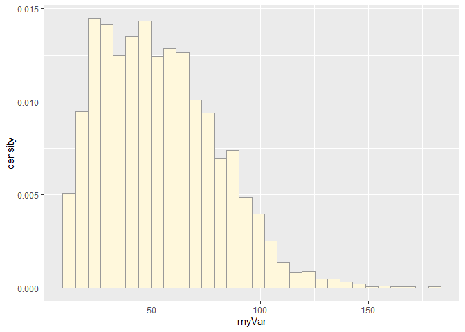

```r
p1 <- ggplot(data=z, aes(x=myVar, y=..density..)) +  # rescale y axis from counts to density (want area under histogram to equal 1)
  geom_histogram(color="grey60",fill="cornsilk",size=0.2)
print(p1)
```

### Add empirical density curve

This does not assume any particular probability distribution, but smooths out to the shape of the histogram.

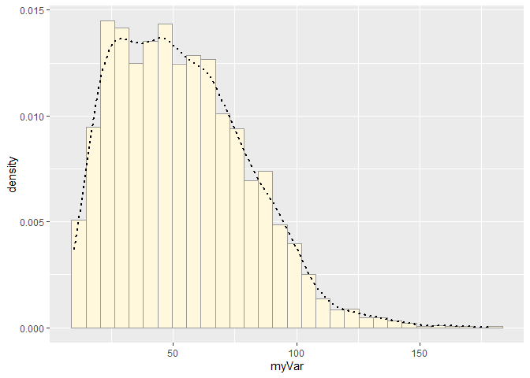

```r
p1 <-  p1 +  geom_density(linetype="dotted",size=0.75)  # add in kernel density plot of data - empirical curve fitted to data
print(p1)
```

### Get maximum likelihood parameters for `normal`

Fit normal distribution and extract maximum likelihood estimators.

```r
normPars <- fitdistr(z$myVar,"normal")  # get maximum likelihood parameters
print(normPars)
```

```
##       mean          sd
##   53.6195855   26.5116955
##  ( 0.4628437) ( 0.3272799)
```

```r
str(normPars)
```

```
## List of 5
##  $ estimate: Named num [1:2] 53.6 26.5
##   ..- attr(*, "names")= chr [1:2] "mean" "sd"
##  $ sd      : Named num [1:2] 0.463 0.327
##   ..- attr(*, "names")= chr [1:2] "mean" "sd"
##  $ vcov    : num [1:2, 1:2] 0.214 0 0 0.107
##   ..- attr(*, "dimnames")=List of 2
##   .. ..$ : chr [1:2] "mean" "sd"
##   .. ..$ : chr [1:2] "mean" "sd"
##  $ n       : int 3281
##  $ loglik  : num -15409
##  - attr(*, "class")= chr "fitdistr"
```

```r
normPars$estimate["mean"] # note structure of getting a named attribute
```

```
##     mean
## 53.61959
```

### Plot `normal` probability density

You can use ggplot’s `stat_function` to add smooth function to any ggplot.

```r
meanML <- normPars$estimate["mean"]
sdML <- normPars$estimate["sd"]

xval <- seq(0,max(z$myVar),len=length(z$myVar))

 stat <- stat_function(aes(x = xval, y = ..y..),
                       fun = dnorm,   # dnorm generates probability density for normal distribution
                       colour="red",  # make best-fitting normal distribution red
                       n = length(z$myVar),
                       args = list(mean = meanML, sd = sdML))
 p1 + stat
```

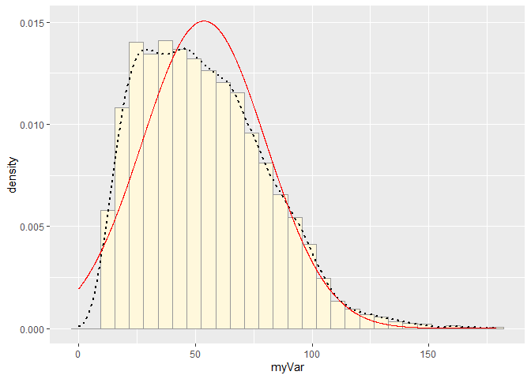

Beware that the best-fitting normal distribution (red curve) might have a biased mean because the data set probably doesn’t have negative values, which will make the normal distribution not work well.

### Plot `exponential` probability density

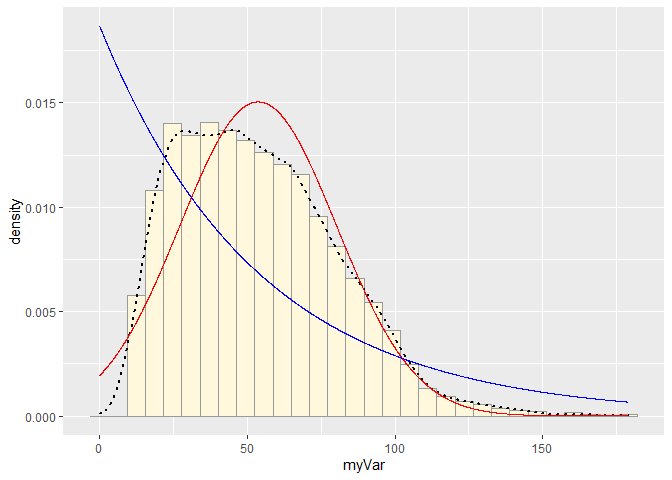

```r
expoPars <- fitdistr(z$myVar,"exponential")
rateML <- expoPars$estimate["rate"]

stat2 <- stat_function(aes(x = xval, y = ..y..), fun = dexp, # use exponential curve instead
                       colour="blue", n = length(z$myVar),
                       args = list(rate=rateML))
 p1 + stat + stat2
```

### Plot `uniform` probability density

Don’t need `fitdistr` here, just the min and max.

```r
stat3 <- stat_function(aes(x = xval, y = ..y..), fun = dunif, colour="darkgreen", n = length(z$myVar), args = list(min=min(z$myVar), max=max(z$myVar)))
 p1 + stat + stat2 + stat3
```

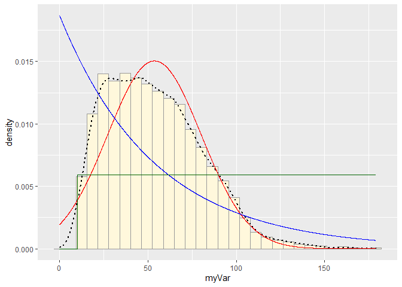

### Plot `gamma` probability density

```r
gammaPars <- fitdistr(z$myVar,"gamma")
shapeML <- gammaPars$estimate["shape"]
rateML <- gammaPars$estimate["rate"]

stat4 <- stat_function(aes(x = xval, y = ..y..), fun = dgamma, colour="brown", n = length(z$myVar), args = list(shape=shapeML, rate=rateML))
 p1 + stat + stat2 + stat3 + stat4
```

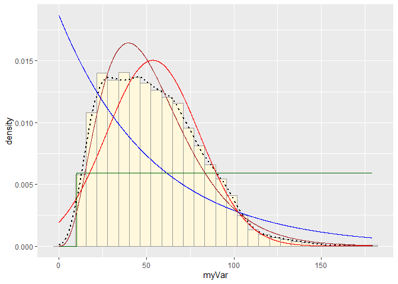

### Plot `beta` probability density

This one goes in its own plot because raw data was rescaled between 0 and 1.

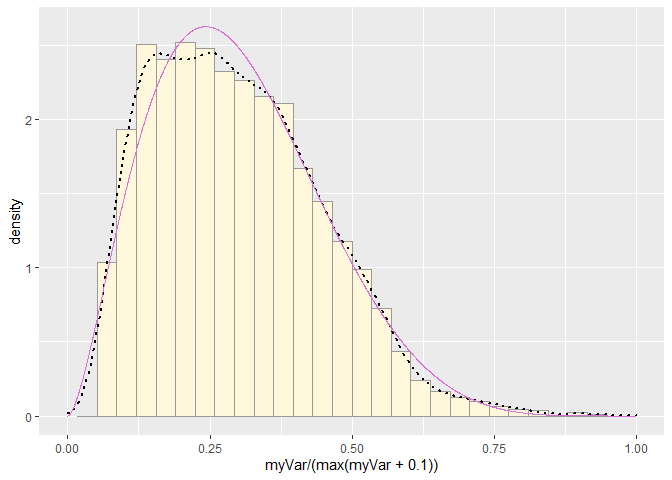

```r
pSpecial <- ggplot(data=z, aes(x=myVar/(max(myVar + 0.1)), y=..density..)) +
  geom_histogram(color="grey60",fill="cornsilk",size=0.2) +
  xlim(c(0,1)) +
  geom_density(size=0.75,linetype="dotted")

betaPars <- fitdistr(x=z$myVar/max(z$myVar + 0.1),start=list(shape1=1,shape2=2),"beta")
shape1ML <- betaPars$estimate["shape1"]
shape2ML <- betaPars$estimate["shape2"]

statSpecial <- stat_function(aes(x = xval, y = ..y..), fun = dbeta, colour="orchid", n = length(z$myVar), args = list(shape1=shape1ML,shape2=shape2ML))
pSpecial + statSpecial
```

### Taking a closer look at the best-fitting distribution

The best-fitting distribution for this data set was the gamma distribution. The beta distribution also fit the data pretty well, but its assumptions may not be realistic.

```r
shapeML <- gammaPars$estimate["shape"]
rateML <- gammaPars$estimate["rate"]

z$new_data_gamma <- rgamma(n=(length(z$ID)), shape = shapeML, rate = rateML)
```

The gamma distribution probability density curve on the simulated data:

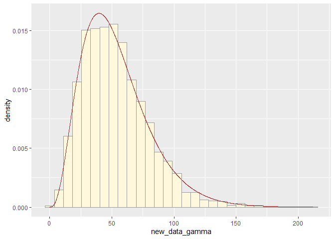

```r
p2 <- ggplot(data=z, aes(x=new_data_gamma, y=..density..)) +
  geom_histogram(color="grey60",fill="cornsilk",size=0.2)
print(p2 + stat4)
```

The gamma distribution probability density curve on the original data:

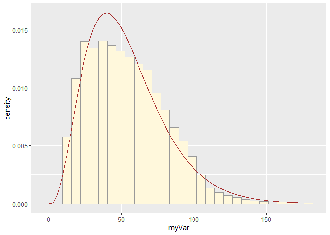

```r
p1 <- ggplot(data=z, aes(x=myVar, y=..density..)) +
  geom_histogram(color="grey60",fill="cornsilk",size=0.2)
print(p1 + stat4)
```

The histogram profiles are very similar, but it appears as though there is more variance in the original data than the simulated data and it is more spread out. There is less of a peak, or in other words, it is more difficult to identify a single mode. Nonetheless, the model does a good job of simulating fairly realistic data. The general shapes are very similar.